# Homework #8

Jules Ford

2023-03-22

**Problem #1**

Since I don’t complete undergrad research in Biology at UVM (my research is with the Philosophy Department) I went online looking for a dataset! I found a cool one on Dryad. [Click here for the dataset](https://datadryad.org/stash/dataset/doi:10.5061%2Fdryad.063h8) and [click here to see the full paper.](https://onlinelibrary.wiley.com/doi/10.1111/jeb.12458)

The study is about variation in nutrient intake for German cockroaches. The three groups of cockroaches observed were wild-type cockroaches, glucose-averse cockroaches, and wild-type x glucose-averse hybrid cockroaches. Researchers measured a variety of metrics, including initial mass, total intake, fat mass, body mass, feces mass, and growth. The cockroaches were fed diets varying in protein content, from low protein to high protein. They were also given different kinds of sugar; some were fed fructose and others were fed glucose.

To keep things simple, I wanted to consider what the differences in total intake would be for each cockroach group, focusing solely on the cockroaches provided a medium-protein diet. A pattern that I would expect from these groups is that the wild-type would have the greatest intake, followed by the hybrid and the glucose-averse cockroaches would have the lowest intake.

**Problem #2**

To come up with numbers that I could potentially expect to support this prediction, I downloaded the dataset and calculated the mean, standard deviation, variance, and sample size for each group:

**Wild-type German cockroach data for medium protein, total intake**

Mean: 11.7636

Standard Deviation: 1.3207022

n: 20

**Hybrid German cockroach data for medium protein, total intake**

Mean: 11.201452

Standard Deviation: 1.1952825

n: 23

**Glucose-averse German cockroach data for medium protein, total intake**

Mean: 6.509735

Standard Deviation: 3.1441545

Variance: 9.8857076

n: 20

**Problem #3**

Next, I need to take these parameters and generate randomized, fake datasets and store them as dataframes. To accomplish this, since we’re assuming these data are on a normal distribution, I’ll use the `rnorm()` function.

This function takes in parameters n (the number of observations), mean (the mean(), and sd (the standard deviation).

The dataset for just the wild-type:

```r
wild_type <- rnorm(n=20,mean=11.7636,sd=1.3207022)
print(wild_type)
```

```
##  [1] 12.150201 11.668608 11.581299 12.439172 11.958783  9.215075 11.320753
##  [8] 10.042070 10.587226 10.334129 12.764314 11.056789 11.816731 13.589461
## [15] 13.291788 12.028202  9.839399 13.037189 10.479722 11.316069
```

The dataset for just the hybrid:

```r
hybrid <- rnorm(n=23,mean=11.201452,sd=1.1952825)
print(hybrid)
```

```
##  [1] 11.139420 10.186961 12.000775 11.328491 11.548918 12.302512 10.464411
##  [8] 13.360964  9.942102 11.267405 12.982376  9.296515  9.729649 10.724141
## [15] 10.027236 12.236502 12.024810 10.404337  9.286378 10.806524 10.099517
## [22]  9.871432 11.800911
```

The dataset for just the glucose-averse:

```r
glucose_averse <- rnorm(n=20,mean=6.509735,sd=3.1441545)
print(glucose_averse)
```

```
##  [1] 11.7694720  6.8395405  0.9529687  7.9485706  7.4380646  3.0463959
##  [7]  8.3839867  3.2935580  5.3038359  8.7259800  5.8695149  8.4604258
## [13]  3.7142000  3.6514236 13.4129961  8.5394912  5.1617166 10.3767179
## [19]  7.5727002  6.2472829
```

And here’s a dataframe of all the roaches together:

```r
library(tidyverse)
```

```r
library(ggplot2)

firstBigFrame <- data.frame("wild.type"= rnorm(n=20,mean=11.7636,sd=1.3207022),"hybrid"=rnorm(n=20,mean=11.201452,sd=1.1952825),"glucose.averse"=rnorm(n=20,mean=6.509735,sd=3.1441545))
print(firstBigFrame)
```

```
##    wild.type    hybrid glucose.averse
## 1  11.102399 10.542705       6.565730
## 2  10.118678 10.263543       7.057407
## 3  10.522206 12.407544       8.474178
## 4  10.736003 12.007259       4.379168
## 5  13.715137 11.601498      12.229658
## 6  15.678770 10.196096      12.224270
## 7   9.924805 10.916228       6.011982
## 8  10.193694 10.261639      13.394578
## 9   9.861614 11.288416       3.037990
## 10 11.732822  9.945814       4.907784
## 11 13.553542 14.871133       9.060739
## 12 12.424483 12.559298       2.512631
## 13 11.983361 11.344535       7.296718
## 14 10.054717 11.173129       9.318496
## 15 10.849852  9.912375       6.850002
## 16 11.949824 11.301819       4.323342
## 17 12.113502 13.085676       3.413667
## 18 12.251552 12.972405      11.595450
## 19 12.361726 10.791447       2.231935
## 20 13.774796 14.889204       6.438323
```

I’m honestly really excited about this step because I was stuck on it for a while. At first my approach was to make individual dataframes for each of the different groups (seen above) but then I realized I could use the `data.frame()` function to combine everything neatly and give titles for each of the three groups. I made the executive decision to reduce the hybrid n to 20 even though it was 23 just to keep everything uniform.

Then, I started problem 4 and realized I ran into a big issue: I needed to pick an x and a y variable. So, I ended up rolling with comparing for each cockroach group the total intake versus their growth. In terms of data analysis, I wanted to see within each group whether there’d be a statistically significant relationship between intake and growth. I predict that GA cockroaches would likely have a significant relationship between intake and growth, and Hybrid and Wild Type cockroaches probably wouldn’t.

To measure this, I decided that I needed to grab more data from the dataset from the “Growth” column:

**Wild-type German cockroach data for medium protein, growth**

Mean: 6.6646158

Standard Deviation: 0.8682219

Variance: 0.7538092

n: 19

**Hybrid German cockroach data for medium protein, growth**

Mean: 7.0736739

Standard Deviation: 1.0584402

Variance: 1.1202956

n: 23

**Glucose-averse German cockroach data for medium protein, growth**

Mean: 3.967465

Standard Deviation: 1.1635215

Variance: 1.3537822

n: 20

So now, the plan is to make this dataframe again but with 6 columns: 3 will show each roach group’s total intake, and 3 will show each group’s growth. Here is the new and improved dataframe:

```r
allTheRoaches <- data.frame("WT.intake"=rnorm(n=20,mean=11.7636,sd=1.3207022),"WT.growth"=rnorm(n=20,mean=6.6646158,sd=0.8682219),"Hyb.intake"=rnorm(n=20,mean=11.201452,sd=1.1952825),"Hyb.growth"=rnorm(n=20,mean=7.0736739,sd=1.0584402),"GA.intake"=rnorm(n=20,mean=6.509735,sd=3.1441545),"GA.growth"=rnorm(n=20,mean=3.967465,sd=1.1635215))
print(allTheRoaches)
```

```
##    WT.intake WT.growth Hyb.intake Hyb.growth GA.intake GA.growth
## 1  12.044886  6.212816  11.158420   7.249286  8.826529  4.371289
## 2  10.861256  7.350461  11.040589   6.686495  5.473140  2.563515
## 3  10.323863  6.300149  11.814614   5.714236  7.558396  4.388556
## 4  10.290105  7.460681  12.893310   6.826856  5.834097  1.872834
## 5  11.875618  6.454015  12.218822   7.543056  5.882357  4.524830
## 6  12.045516  5.767168  14.293584   8.487819 12.360426  2.890409
## 7  12.149180  7.338453  11.947121   7.269627  4.527038  3.254587
## 8  12.205609  6.071437  10.366118   7.792234 10.770769  4.354533
## 9  11.826694  6.206120  12.458362   8.444260  6.339304  3.076416
## 10 10.869893  7.186814  11.763753   9.049170  8.173097  4.517665
## 11 12.498807  7.953408  11.703451   8.441484  7.850210  5.663738
## 12 10.839621  6.353631  13.467601   5.195755  3.498771  5.141425
## 13 12.702776  5.424154  11.784201   7.435160  6.299948  2.791004
## 14 11.481880  7.618241  10.092109   5.608236  5.270900  5.162768
## 15 11.477366  6.771008   9.902904   7.770461 11.619197  4.080678
## 16 10.738052  5.351813  13.305459   9.340053  6.202026  1.633884
## 17 12.346025  6.199168  10.849718   3.459335  7.452973  3.994305
## 18  9.616663  7.390666  13.464384   6.331220  7.004595  3.004494
## 19  9.152785  6.880312  11.043438   7.674110  3.410951  1.861424
## 20 11.227583  5.719751  12.265652   7.361549  4.818695  3.579992
```

**Problem #4**

Now that I have the proper dataframe to work with, I want to analyze the data and make graphs for each group:

```r
# Regression analysis on each group
lm_WT <- lm(WT.growth ~ WT.intake, data=allTheRoaches)
summary(lm_WT)
```

```
##
## Call:
## lm(formula = WT.growth ~ WT.intake, data = allTheRoaches)
##
## Residuals:
##     Min      1Q  Median      3Q     Max
## -1.3626 -0.3936 -0.1724  0.5383  1.5784
##
## Coefficients:
##             Estimate Std. Error t value Pr(>|t|)
## (Intercept)   8.7843     2.0338   4.319 0.000413 ***
## WT.intake    -0.1928     0.1789  -1.078 0.295481
## ---
## Signif. codes:  0 '***' 0.001 '**' 0.01 '*' 0.05 '.' 0.1 ' ' 1
##
## Residual standard error: 0.7618 on 18 degrees of freedom
## Multiple R-squared:  0.06059,    Adjusted R-squared:  0.008404
## F-statistic: 1.161 on 1 and 18 DF,  p-value: 0.2955
```

```r
lm_Hyb <- lm(Hyb.growth ~ Hyb.intake, data=allTheRoaches)
summary(lm_Hyb)
```

```
##
## Call:
## lm(formula = Hyb.growth ~ Hyb.intake, data = allTheRoaches)
##
## Residuals:
##     Min      1Q  Median      3Q     Max
## -3.4756 -0.7338  0.2587  0.9951  1.8957
##
## Coefficients:
##             Estimate Std. Error t value Pr(>|t|)
## (Intercept)   4.3415     3.2643   1.330    0.200
## Hyb.intake    0.2390     0.2732   0.875    0.393
##
## Residual standard error: 1.418 on 18 degrees of freedom
## Multiple R-squared:  0.04079,    Adjusted R-squared:  -0.0125
## F-statistic: 0.7655 on 1 and 18 DF,  p-value: 0.3931
```

```r
lm_GA <- lm(GA.growth ~ GA.intake, data=allTheRoaches)
summary(lm_GA)
```

```
##
## Call:
## lm(formula = GA.growth ~ GA.intake, data = allTheRoaches)
##
## Residuals:
##     Min      1Q  Median      3Q     Max
## -1.9356 -0.8258  0.0825  0.7178  1.9485
##
## Coefficients:
##             Estimate Std. Error t value Pr(>|t|)
## (Intercept)  3.02119    0.80450   3.755  0.00145 **
## GA.intake    0.08841    0.10927   0.809  0.42901
## ---
## Signif. codes:  0 '***' 0.001 '**' 0.01 '*' 0.05 '.' 0.1 ' ' 1
##
## Residual standard error: 1.175 on 18 degrees of freedom
## Multiple R-squared:  0.03509,    Adjusted R-squared:  -0.01851
## F-statistic: 0.6547 on 1 and 18 DF,  p-value: 0.429
```

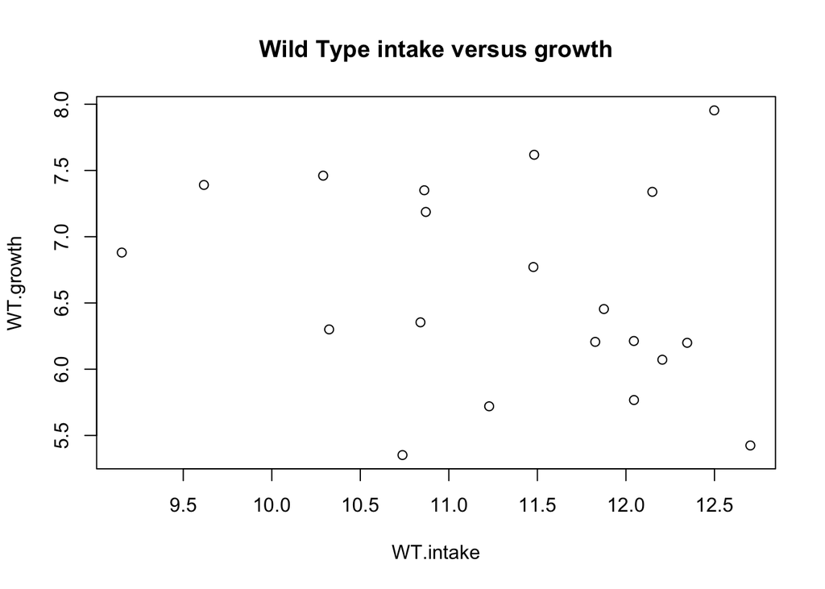

```r
wt_scatter <- plot(WT.growth ~ WT.intake, main = "Wild Type intake versus growth", data=allTheRoaches)
```

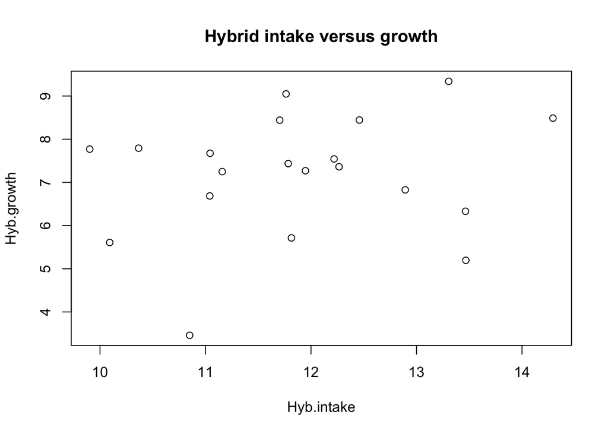

```r
hyb_scatter <- plot(Hyb.growth ~ Hyb.intake, main = "Hybrid intake versus growth", data=allTheRoaches)
```

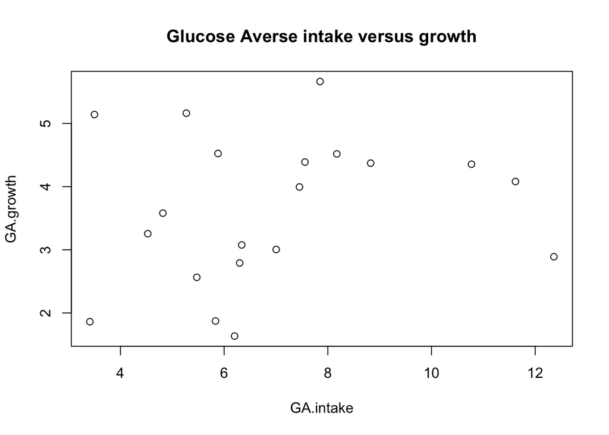

```r
ga_scatter <- plot(GA.growth ~ GA.intake, main = "Glucose Averse intake versus growth", data=allTheRoaches)
```

I used `lm()` make linear models for each group and I used `plot()` to make scatterplots for each group. One thing I’d like to learn in the future is how to incorporate the `abline()` function to include a line of best fit, and how to group each of the columns in the dataset into a single plot. (I’ve done both of these in the past but I was having trouble figuring out how to do this.)

**Problem #5**

This problem asks us to run the analysis a few times without changing parameters but using different randomized numbers. Here are the p-values for each group after running it three times:

WT p-values: 0.04576, 0.5647, 0.7041 Hybrid p-values: 0.4899, 0.6637, 0.6362 GA p-values: 0.1966, 0.8681, 0.649

It seems that for each group, it isn’t super likely that there’s a statistically significant relationship between intake and growth. The only time that it was statistically significant was with one of the trials for the WT cockroaches, which was one of the groups I wasn’t expecting to have a statistically significant relationship.

**Problem #6**

This problem asks us to adjust the means of the groups to see how small the differences between the groups can be to still produce a significant difference. I don’t think adjusting the means to become closer to each other will lead to a significant difference given that the original dataset is not significant, but here goes!

To do this, I decreased the WT and Hybrid intake means by 1 and increased the GA intake mean by 1. I decreased the WT and Hybrid growth by 1 and increased the GA growth by 1.

```r
smallerMeanRoaches <- data.frame("WT.intake.s"=rnorm(n=100,mean=10.7636,sd=1.3207022),"WT.growth.s"=rnorm(n=100,mean=5.6646158,sd=0.8682219),"Hyb.intake.s"=rnorm(n=100,mean=10.201452,sd=1.1952825),"Hyb.growth.s"=rnorm(n=100,mean=6.0736739,sd=1.0584402),"GA.intake.s"=rnorm(n=100,mean=7.509735,sd=3.1441545),"GA.growth.s"=rnorm(n=100,mean=4.967465,sd=1.1635215)) # .s suffix is a reminder that it's a smaller differences between means

lm_smaller_WT <- lm(WT.growth.s ~ WT.intake.s, data=smallerMeanRoaches)
summary(lm_smaller_WT)
```

```
##
## Call:
## lm(formula = WT.growth.s ~ WT.intake.s, data = smallerMeanRoaches)
##
## Residuals:
##      Min       1Q   Median       3Q      Max
## -1.45242 -0.54159  0.00411  0.58788  1.43097
##
## Coefficients:
##             Estimate Std. Error t value Pr(>|t|)
## (Intercept)  5.54936    0.62925   8.819 4.41e-14 ***
## WT.intake.s  0.01361    0.05839   0.233    0.816
## ---
## Signif. codes:  0 '***' 0.001 '**' 0.01 '*' 0.05 '.' 0.1 ' ' 1
##
## Residual standard error: 0.781 on 98 degrees of freedom
## Multiple R-squared:  0.0005539,  Adjusted R-squared:  -0.009645
## F-statistic: 0.05431 on 1 and 98 DF,  p-value: 0.8162
```

```r
lm_smaller_Hyb <- lm(Hyb.growth.s ~ Hyb.intake.s, data=smallerMeanRoaches)
summary(lm_smaller_Hyb)
```

```
##
## Call:
## lm(formula = Hyb.growth.s ~ Hyb.intake.s, data = smallerMeanRoaches)
##
## Residuals:
##      Min       1Q   Median       3Q      Max
## -2.28412 -0.55938  0.05657  0.59653  2.60016
##
## Coefficients:
##              Estimate Std. Error t value Pr(>|t|)
## (Intercept)   5.70392    0.79008   7.219 1.13e-10 ***
## Hyb.intake.s  0.04527    0.07725   0.586    0.559
## ---
## Signif. codes:  0 '***' 0.001 '**' 0.01 '*' 0.05 '.' 0.1 ' ' 1
##
## Residual standard error: 0.968 on 98 degrees of freedom
## Multiple R-squared:  0.003492,   Adjusted R-squared:  -0.006676
## F-statistic: 0.3435 on 1 and 98 DF,  p-value: 0.5592
```

```r
lm_smaller_GA <- lm(GA.growth.s ~ GA.intake.s, data=smallerMeanRoaches)
summary(lm_smaller_GA)
```

```
##
## Call:
## lm(formula = GA.growth.s ~ GA.intake.s, data = smallerMeanRoaches)
##
## Residuals:
##     Min      1Q  Median      3Q     Max
## -2.9992 -0.7426 -0.0915  0.7837  3.3847
##
## Coefficients:
##             Estimate Std. Error t value Pr(>|t|)
## (Intercept)  4.80389    0.29815  16.112   <2e-16 ***
## GA.intake.s  0.01838    0.03518   0.522    0.603
## ---
## Signif. codes:  0 '***' 0.001 '**' 0.01 '*' 0.05 '.' 0.1 ' ' 1
##
## Residual standard error: 1.189 on 98 degrees of freedom
## Multiple R-squared:  0.002777,   Adjusted R-squared:  -0.007399
## F-statistic: 0.2729 on 1 and 98 DF,  p-value: 0.6026
```

Here are the p-values for each group after running it three times:

WT p-values: 0.8275, 0.137, 0.7171 Hybrid p-values: 0.167, 0.8591, 0.7895 GA p-values: 0.9586, 0.4543, 0.1322

Unsurprisingly it doesn’t seem like there are any significant trends in p-values for each of the groups.

**Problem #7**

This problem asks us to adjust the sample size to see how small our sample sizes can be to detect a statistically significant pattern. Since the data for each group are currently not generating statistically significant results, I wanted to run this by actually increasing the sample sizes for each group and seeing if the results become statistically significant at a larger n.

```r
largerSizeRoaches <- data.frame("WT.intake.n"=rnorm(n=100,mean=11.7636,sd=1.3207022),"WT.growth.n"=rnorm(n=100,mean=6.6646158,sd=0.8682219),"Hyb.intake.n"=rnorm(n=100,mean=11.201452,sd=1.1952825),"Hyb.growth.n"=rnorm(n=100,mean=7.0736739,sd=1.0584402),"GA.intake.n"=rnorm(n=100,mean=6.509735,sd=3.1441545),"GA.growth.n"=rnorm(n=100,mean=3.967465,sd=1.1635215)) # .n suffix is a reminder that it's a larger sample size

lm_larger_WT <- lm(WT.growth.n ~ WT.intake.n, data=largerSizeRoaches)
summary(lm_larger_WT)
```

```
##
## Call:
## lm(formula = WT.growth.n ~ WT.intake.n, data = largerSizeRoaches)
##
## Residuals:
##      Min       1Q   Median       3Q      Max
## -1.75668 -0.59616 -0.06862  0.59722  2.55988
##
## Coefficients:
##             Estimate Std. Error t value Pr(>|t|)
## (Intercept)  5.70457    0.73687   7.742 8.99e-12 ***
## WT.intake.n  0.07974    0.06124   1.302    0.196
## ---
## Signif. codes:  0 '***' 0.001 '**' 0.01 '*' 0.05 '.' 0.1 ' ' 1
##
## Residual standard error: 0.8321 on 98 degrees of freedom
## Multiple R-squared:  0.01701,    Adjusted R-squared:  0.006979
## F-statistic: 1.696 on 1 and 98 DF,  p-value: 0.1959
```

```r
lm_larger_Hyb <- lm(Hyb.growth.n ~ Hyb.intake.n, data=largerSizeRoaches)
summary(lm_larger_Hyb)
```

```
##
## Call:
## lm(formula = Hyb.growth.n ~ Hyb.intake.n, data = largerSizeRoaches)
##
## Residuals:
##      Min       1Q   Median       3Q      Max
## -2.30612 -0.71208 -0.08441  0.59419  2.04654
##
## Coefficients:
##              Estimate Std. Error t value Pr(>|t|)
## (Intercept)   7.81605    0.86742   9.011  1.7e-14 ***
## Hyb.intake.n -0.04262    0.07722  -0.552    0.582
## ---
## Signif. codes:  0 '***' 0.001 '**' 0.01 '*' 0.05 '.' 0.1 ' ' 1
##
## Residual standard error: 0.9447 on 98 degrees of freedom
## Multiple R-squared:  0.003099,   Adjusted R-squared:  -0.007073
## F-statistic: 0.3047 on 1 and 98 DF,  p-value: 0.5822
```

```r
lm_larger_GA <- lm(GA.growth.n ~ GA.intake.n, data=largerSizeRoaches)
summary(lm_larger_GA)
```

```
##
## Call:
## lm(formula = GA.growth.n ~ GA.intake.n, data = largerSizeRoaches)
##
## Residuals:
##     Min      1Q  Median      3Q     Max
## -2.9099 -0.7152  0.2108  0.7121  1.7724
##
## Coefficients:
##             Estimate Std. Error t value Pr(>|t|)
## (Intercept)  4.24254    0.24178  17.547   <2e-16 ***
## GA.intake.n  0.01385    0.03581   0.387      0.7
## ---
## Signif. codes:  0 '***' 0.001 '**' 0.01 '*' 0.05 '.' 0.1 ' ' 1
##
## Residual standard error: 1.098 on 98 degrees of freedom
## Multiple R-squared:  0.001524,   Adjusted R-squared:  -0.008665
## F-statistic: 0.1495 on 1 and 98 DF,  p-value: 0.6998
```

Here are the p-values for each group after running it three times:

WT p-values: 0.3797, 0.1618, 0.5585

Hybrid p-values: 0.2949, 0.8096, 0.1523

GA p-values: 0.9596, 0.8306, 0.9036

The thing I like about these results is that they feel more consistent then the data from earlier. But I want to run it once more with an even larger sample size to see what happens:

```r
hugeSizeRoaches <- data.frame("WT.intake.nn"=rnorm(n=1000,mean=11.7636,sd=1.3207022),"WT.growth.nn"=rnorm(n=1000,mean=6.6646158,sd=0.8682219),"Hyb.intake.nn"=rnorm(n=1000,mean=11.201452,sd=1.1952825),"Hyb.growth.nn"=rnorm(n=1000,mean=7.0736739,sd=1.0584402),"GA.intake.nn"=rnorm(n=1000,mean=6.509735,sd=3.1441545),"GA.growth.nn"=rnorm(n=1000,mean=3.967465,sd=1.1635215)) # .nn suffix is a reminder that it's an even larger sample size

lm_huge_WT <- lm(WT.growth.nn ~ WT.intake.nn, data=hugeSizeRoaches)
summary(lm_huge_WT)
```

```
##
## Call:
## lm(formula = WT.growth.nn ~ WT.intake.nn, data = hugeSizeRoaches)
##
## Residuals:
##      Min       1Q   Median       3Q      Max
## -2.91432 -0.52862  0.00118  0.55847  2.72631
##
## Coefficients:
##               Estimate Std. Error t value Pr(>|t|)
## (Intercept)   6.610314   0.225836  29.270   <2e-16 ***
## WT.intake.nn -0.001014   0.019113  -0.053    0.958
## ---
## Signif. codes:  0 '***' 0.001 '**' 0.01 '*' 0.05 '.' 0.1 ' ' 1
##
## Residual standard error: 0.8301 on 998 degrees of freedom
## Multiple R-squared:  2.821e-06,  Adjusted R-squared:  -0.0009992
## F-statistic: 0.002816 on 1 and 998 DF,  p-value: 0.9577
```

```r
lm_huge_Hyb <- lm(Hyb.growth.nn ~ Hyb.intake.nn, data=hugeSizeRoaches)
summary(lm_huge_Hyb)
```

```
##
## Call:
## lm(formula = Hyb.growth.nn ~ Hyb.intake.nn, data = hugeSizeRoaches)
##
## Residuals:
##     Min      1Q  Median      3Q     Max
## -3.3412 -0.6878 -0.0043  0.6350  3.4386
##
## Coefficients:
##               Estimate Std. Error t value Pr(>|t|)
## (Intercept)    6.65985    0.29345  22.695   <2e-16 ***
## Hyb.intake.nn  0.03722    0.02602   1.431    0.153
## ---
## Signif. codes:  0 '***' 0.001 '**' 0.01 '*' 0.05 '.' 0.1 ' ' 1
##
## Residual standard error: 1.038 on 998 degrees of freedom
## Multiple R-squared:  0.002046,   Adjusted R-squared:  0.001046
## F-statistic: 2.047 on 1 and 998 DF,  p-value: 0.1529
```

```r
lm_huge_GA <- lm(GA.growth.nn ~ GA.intake.nn, data=hugeSizeRoaches)
summary(lm_huge_GA)
```

```
##
## Call:
## lm(formula = GA.growth.nn ~ GA.intake.nn, data = hugeSizeRoaches)
##
## Residuals:
##     Min      1Q  Median      3Q     Max
## -4.4079 -0.7799 -0.0248  0.7603  3.4355
##
## Coefficients:
##               Estimate Std. Error t value Pr(>|t|)
## (Intercept)   3.959122   0.084785  46.696   <2e-16 ***
## GA.intake.nn -0.001081   0.011883  -0.091    0.928
## ---
## Signif. codes:  0 '***' 0.001 '**' 0.01 '*' 0.05 '.' 0.1 ' ' 1
##
## Residual standard error: 1.137 on 998 degrees of freedom
## Multiple R-squared:  8.293e-06,  Adjusted R-squared:  -0.0009937
## F-statistic: 0.008277 on 1 and 998 DF,  p-value: 0.9275
```

Here are the p-values for each group after running it three times:

WT p-values: 0.3884, 0.9436, 0.6803

Hybrid p-values: 0.2677, 0.006802, 0.297

GA p-values: 0.4927, 0.04421, 0.521

This honestly felt pretty inconsistent as well, I think overall I’m going to conclude that there aren’t likely statistically significant relationships for each of these groups! (Despite a few low and very low p-values, since no group is consistently low it doesn’t make sense to reject the null hypothesis.)

**Problem #8**

(Just asks us to ensure our write-up on this homework is thorough.)

**Problem #9**

I didn’t have time for this part of the problem unfortunately!